# R Package Development

Michael Tiefelsdorf

July 7, 2020

# 1 Preamble

Two sources are used in this tutorial, which shows you how to build and distribute your package:

  The package building procedure is substantially simplified using `New Projects -> Packages` and the `Build` tap in **RStudio**.

  This streamlined procedure is documented Hadley Wickham *R Packages. Organize, test document and share your code* (see http://r-pkgs.had.co.nz).

  A cheat-sheet is available at https://github.com/rstudio/cheatsheets/raw/master/package-development.pdf.

# 2 Why to distribute your code and data in an `R`-package?

- Advantages of packages:
  - Structured development procedure, which promotes *reproducible* research.
  - Enforced documentation of functions, data and perhaps application examples using vignettes.
  - Easy distribution of as `*.tar.gz`. The source code remains still visible.
- Advantages of posting at `CRAN`:
  - Automated plus human peer-review to guarantee consistency.
  - Can count as publication
  - Broadly available to the professional and academic community for use and peer-review.
- Disadvantages:
  - For final releases only - not for development cycles, for which `github` is more appropriate.
  - You are limited to a set of open-source `C++`, `Fortran` etc. compilers, if you incorporate low-level code into your package.
  - Work, work, work … and more WORK!

# 3 Installing the Bundled Package `npar`

Make sure that the `Rtools` for your current version of `R` are installed on your computer: See https://cran.r-project.org/bin/windows/Rtools/installer.html. These tools allow you to build *bundled* or *binary* packages.

- Bundles packages have the extension `*.tar.gz` and can be installed in `R` for any operating system. The `Rtools` are needed to install bundles.

  *Important*: If a library is installed from a bundle, *dependent packages* are not installed and must be manually downloaded and installed. A dependent package is a library on which the your current package depends in order to run properly.
- Binary packages are specific to the operating system. For instance, for Window’s `R` implementations they have the extension `*.zip`. These libraries automatically install dependent packages. Note: Sometimes $\LaTeX$ equations in the documentation is not properly transcribed.

There is subtle difference in the terminology:

- A *package* is a collection of files, which are organized in a directory structure, making up the add-on.
- Whereas a *library* is the physical installation of the package in R’s library system on the hard-drive.

The syntax for installing an `R` package at the command prompt from file is `install.packages( )` with the directory and file name following the `R` convention and the important option `repos=NULL`:

```r
> install.packages("F:\\Lectures2020\\EPPS6324\\CreatingPackage\\npar_1.0.tar.gz", repos=NULL)
```

```
R> Installing package into 'C:/Users/Michael/Documents/R/win-library/3.5'
R> (as 'lib' is unspecified)
```

[output not shown]

You will receive in R’s console the following installation log:

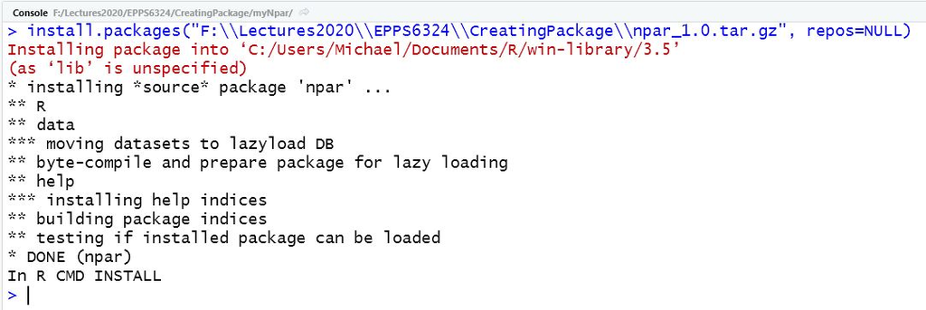

Subsequently, you need to attach the library to your `R`-session:

```r
> library(npar)
```

# 4 Test-driving the Library `npar`

Please open the documentation of the library `npar`: *Non parametric group comparison* in `R`’s help system. You will see the follow links:

[figure not shown]

Description of `npar`’s content:

- A DESCRIPTION file with meta information.
- Data in `life`: Female (`hlef`) and male (`hlem`) life expectancy of of persons age 65 in years by state (2007 to 2009)
- Bundle S3 function objects, i.e., `oneway`, `summary.oneway`, `print.oneway` to compare the life expectancy with non-parametric statistical methods.
- Specialized plot function `plot.oneway` to visualize the data.

Evaluating the overall life expectancy distribution:

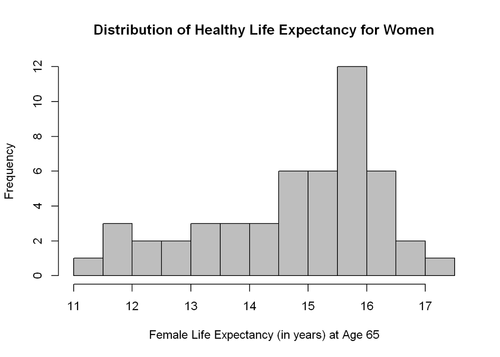

```r
> hist(life$hlef, xlab="Female Life Expectancy (in years) at Age 65",
+      main="Distribution of Healthy Life Expectancy for Women",
+      col="grey", breaks=10)
```

The data are negatively skewed, which violates the normal distribution assumption of the classical *t*-test. Thus a non parametric comparison procedure must be used.

Distribution of the female life expectancy by region with `ggplot` gives

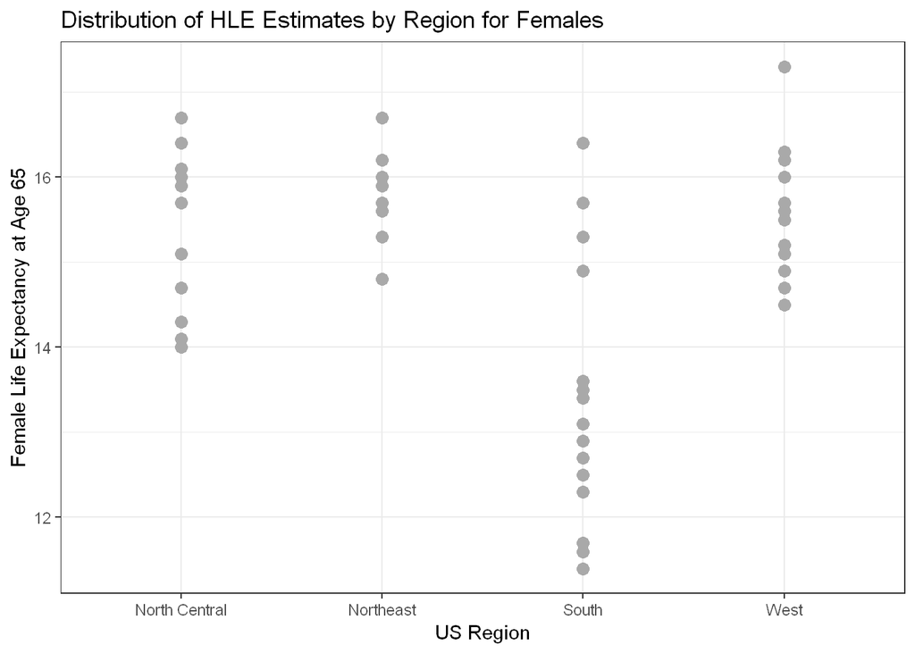

```r
> ggplot(data=life, aes(x=region, y=hlef)) +
+        geom_point(size=3, color="darkgrey") +
+        labs(title="Distribution of HLE Estimates by Region for Females",
+             x="US Region", y="Female Life Expectancy at Age 65") +
+        theme_bw()
```

or with the `npar::plot` function give

```r
> results <- oneway(hlef ~ region, life)
> summary(results)
```

```
R> data: hlef on region
R>
R> Omnibus Test
R> Kruskal-Wallis chi-squared = 17.8749, df = 3, p-value = 0.0004668
R>
R> Descriptive Statistics
R>          South North Central    West Northeast
R> n      16.0000      12.00000 13.0000   9.00000
R> median 13.0000      15.40000 15.6000  15.70000
R> mad     1.4826       1.26021  0.7413   0.59304
R>
R> Multiple Comparisons (Wilcoxon Rank Sum Tests)
R> Probability Adjustment = holm
R>         Group.1       Group.2    W           p
R> 1         South North Central 28.0 0.008583179 **
R> 2         South          West 27.0 0.004737844 **
R> 3         South     Northeast 17.0 0.008583179 **
R> 4 North Central          West 63.5 1.000000000
R> 5 North Central     Northeast 42.0 1.000000000
R> 6          West     Northeast 54.5 1.000000000
R> ---
R> Signif. codes:  0 '***' 0.001 '**' 0.01 '*' 0.05 '.' 0.1 ' ' 1
```

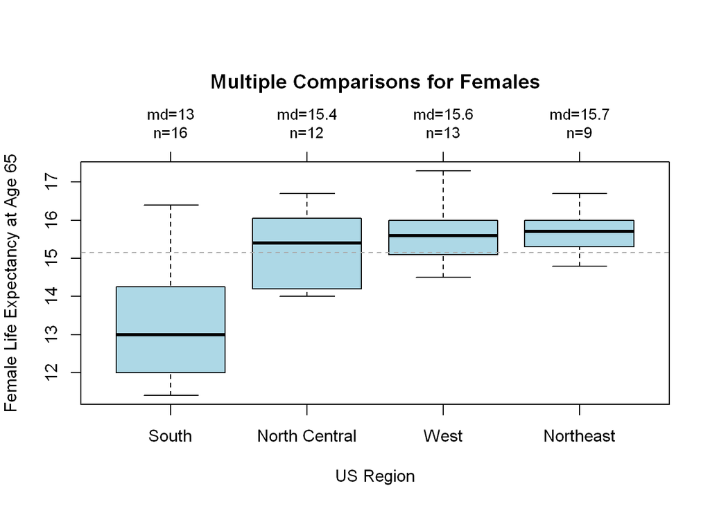

```r
> plot(results, col="lightblue", main="Multiple Comparisons for Females",
+      xlab="US Region", ylab="Female Life Expectancy at Age 65")
```

# 5 Tools to Build Libraries

Several external tools and library are needed to build packages with `RStudio`:

- `Rtools` is needed for Windows computers. It is a stand-alone program. Mac and Linux computers *may* have different requirements. Click [here](http://r-pkgs.had.co.nz/intro.html#intro-get) for more information.
- It *may* be required to install external $\LaTeX$ editor programs. For Windows see [MiTeX](http://miktex.org) and for Mac see MacTeX if you include mathematical equations in your documentation.

The required libraries below are part of the standard installation of **RStudio**:

- The library `roxygen2` to build the data and function help files.
- The library `devtools` with automates building a package.
- See also the [package development prerequisits](https://support.rstudio.com/hc/en-us/articles/200486498)

# 6 Functions and Data of `npar`’s Source Code

Each function has a header with standardized information *tags* for its *help-file*. Each documentation line is preceded by the characters `#'`. Functions in the library `roxygen2` will use this information to generate the function’s help documentation.

The online help `Help > Roxygen Quick Reference` list the most commonly used keyword of function documentations.

## 6.1 The `oneway` Function

Please open the online help of the `oneway` function in `R` help-system.

The function `oneway` is the *workhorse* of the package.

The function’s header with controlling tags is followed by an example function call and subsequently the `R` source code:

```
#' @title Nonparametric group comparisons
#'
#' @description
#' \code{oneway} computes nonparametric group comparisons, including an
#' omnibus test and post-hoc pairwise group comparisons.
#'
#' @details
#' This function computes an omnibus Kruskal-Wallis test that the
#' groups are equal, followed by all pairwise comparisons using
#' Wilcoxon Rank Sum tests. Exact Wilcoxon tests can be requested if
#' there are no ties on the dependent variable. The p-values are
#' adjusted for mulitple comparisons using the \code{\link{p.adjust}}
#' function.
#'
#' @param formula an object of class formula, relating the dependent variable
#' to the grouping variable.
#' @param data a data frame containing the variables in the model.
#' @param exact logical. If \code{TRUE}, calculate exact Wilcoxon tests.
#' @param sort logical. If \code{TRUE}, sort groups by median dependent variable values.
#' @param method method for correcting p-values for multiple comparisons.
#'
#' @return a list with 7 elements:
#' \item{CALL}{function call}
#' \item{data}{data frame containing the depending and grouping variable}
#' \item{sumstats}{data frame with descriptive statistics by group}
#' \item{kw}{results of the Kruskal-Wallis test}
#' \item{method}{method used to adjust p-values}
#' \item{wmc}{data frame containing the multiple comparisons}
#' \item{vnames}{variable names}
#' @author Rob Kabacoff <rkabacoff@@statmethods.net>
#' @export
#'
#' @examples
#' results <- oneway(hlef ~ region, life)
#' summary(results)
#' plot(results, col="lightblue", main="Multiple Comparisons",
#'      xlab="US Region", ylab="Healthy Life Expectancy at Age 65")


oneway <- function(formula, data, exact=FALSE, sort=TRUE,
```

[output cut: 33 more lines]

```
      # note the [[]] to return a single number
      wmc <- rbind(wmc, r)
    }
  }
  wmc$p <- p.adjust(wmc$p, method=method)

  data <- data.frame(y, g)
  names(data) <- vnames
  results <- list(CALL = match.call(),
                  data=data,
                  sumstats=sumstats, kw=kw,
                  method=method, wmc=wmc, vnames=vnames)
  class(results) <- c("oneway", "list")
  return(results)
}
```

The `@export` tag is important. It makes the function available and adds it to the `NAMESPACE`. This allows other `R` functions to see `oneway`.

For information on S3 class objects and their function system (a.k.a *methods*) please see Kabacoff *Section 20.3: Object oriented programming*.

You can see a library-functions source code without the `roxgen` tags by issuing at the command prompt:

```r
> npar::oneway
```

```
R> function (formula, data, exact = FALSE, sort = TRUE, method = c("holm",
R>     "hochberg", "hommel", "bonferroni", "BH", "BY", "fdr", "none"))
R> {
R>     if (missing(formula) || class(formula) != "formula" || length(all.vars(formula)) !=
R>         2)
R>         stop("'formula' is missing or incorrect")
R>     method <- match.arg(method)
R>     df <- model.frame(formula, data)
R>     y <- df[[1]]
R>     g <- as.factor(df[[2]])
R>     vnames <- names(df)
R>     if (sort)
R>         g <- reorder(g, y, FUN = median)
R>     groups <- levels(g)
R>     k <- nlevels(g)
R>     getstats <- function(x) (c(N = length(x), Median = median(x),
R>         MAD = mad(x)))
R>     sumstats <- t(aggregate(y, by = list(g), FUN = getstats)[2])
R>     rownames(sumstats) <- c("n", "median", "mad")
R>     colnames(sumstats) <- groups
R>     kw <- kruskal.test(formula, data)
R>     wmc <- NULL
R>     for (i in 1:(k - 1)) {
R>         for (j in (i + 1):k) {
R>             y1 <- y[g == groups[i]]
R>             y2 <- y[g == groups[j]]
R>             test <- wilcox.test(y1, y2, exact = exact)
R>             r <- data.frame(Group.1 = groups[i], Group.2 = groups[j],
R>                 W = test$statistic[[1]], p = test$p.value)
R>             wmc <- rbind(wmc, r)
R>         }
R>     }
R>     wmc$p <- p.adjust(wmc$p, method = method)
R>     data <- data.frame(y, g)
R>     names(data) <- vnames
R>     results <- list(CALL = match.call(), data = data, sumstats = sumstats,
R>         kw = kw, method = method, wmc = wmc, vnames = vnames)
R>     class(results) <- c("oneway", "list")
R>     return(results)
R> }
R> <bytecode: 0x0000000012cb7858>
R> <environment: namespace:npar>
```

## 6.2 The `summary.oneway` function

Please open the online help of the `summary.oneway` function in `R` help-system.

This function prints the results of the `oneway` function in an organized fashion into `R`’s Console screen. It is tightly linked to the object class `oneway` and only work for objects from this class.

The keyword `@method summary oneway` in the header establishes the connection. It is shown in the `NAMESPACE`.

The query `inherits(object, "oneway")` in the source code checks whether the input object is of the proper class.

```
#' @title Summarize oneway nonparametric analyses
#'
#' @description
#' \code{summary.oneway} summarizes the results of a oneway
#' nonparametric analysis.
#'
#' @details
#' This function prints a summary of analyses produced by
#' the \code{\link{oneway}} function. This includes descriptive
#' statistics by group, an omnibus Kruskal-Wallis test, and
#' Wilcoxon pairwise multiple comparisons.
#'
#' @param object an object of class \code{oneway}.
#' @param ... additional parameters.
#' @return the input object is returned silently.
#' @author Rob Kabacoff <rkabacoff@@statmethods.net>
#' @method summary oneway
#' @export
#'
#' @examples
#' results <- oneway(hlef ~ region, life)
#' summary(results)

summary.oneway <- function(object, ...){
  if (!inherits(object, "oneway"))
    stop("Object must be of class 'oneway'")

  if(!exists("digits")) digits <- 4L

  kw <- object$kw
  wmc <- object$wmc

  cat("data:", object$vnames[1], "on", object$vnames[2], "\n\n")

  cat("Omnibus Test\n")
  cat(paste("Kruskal-Wallis chi-squared = ",
             round(kw$statistic,4),
            ", df = ", round(kw$parameter, 3),
            ", p-value = ",
               format.pval(kw$p.value, digits = digits),
            "\n\n", sep=""))

  cat("Descriptive Statistics\n")
  print(object$sumstats, ...)


  wmc$stars <- " "
  wmc$stars[wmc$p <   .1] <- "."
  wmc$stars[wmc$p <  .05] <- "*"
  wmc$stars[wmc$p <  .01] <- "**"
  wmc$stars[wmc$p < .001] <- "***"
  names(wmc)[which(names(wmc)=="stars")] <- " "

  cat("\nMultiple Comparisons (Wilcoxon Rank Sum Tests)\n")
  cat(paste("Probability Adjustment = ", object$method, "\n", sep=""))
  print(wmc, ...)
  cat("---\nSignif. codes:  0 '***' 0.001 '**' 0.01 '*' 0.05 '.' 0.1 ' ' 1\n")
}
```

The `print.oneway` function and the `plot.oneway` function follow the same logic.

The `print.oneway`, `plot.oneway` and the `summary.oneway` functions for the object class `oneway` can be called in `R` simply by their generic names `print`, `plot` or `summary`.

## 6.3 The data `life.rda` and its help file `life.r`

Data-sets, which reside in the separate sub-directory `.\\data`, have no provision to include a their documentation directly with the data. Therefore, a helper function with the same *root name* is required. The header syntax of the data-set documentations varies slightly.

[output not shown]

It is important that the header ends with the statement `NULL`.

# 7 Building the `npar` package with **RStudio**

A full documentation on building packages in **RStudio** can be found online at in the first few chapters of [Wickham’s R Packages](http://r-pkgs.had.co.nz/) book. The last few chapters cover more specialized topics. For our purposes, however, our tutorial *R Package Development* and Kabacoff’s “Chapter 21: Creating a package” should be sufficient.

Compared to Kabacoff’s instructions, using **RStudio** makes building a package more streamlined.

From here on, a second instance of **RStudio** will be opened that allows us to re-build the package `npar` with the new name `myNpar`.

## 7.1 Start a New Project

Start a new project following `RStudio`’s menu `File > New Project > New Directory > Package with devtools` and then select the the name of your package. Here `myNpar` has been selected.

[figure not shown]

[figure not shown]

These steps generate a new sub-directory, which has the content:

[figure not shown]

It generated a template

- DESCRIPTION file, which you edit later, and
- a NAMESPACE file which is managed by `Roxygen2`. In general, there is **no need for you** to modify this file!

## 7.2 Populating the Package with Data and Functions

The required data and functions including their `Roxyeng` header information can be found the zipped file `npar-1.0.Source.zip`.

- Inside the package directory generate a new sub-directory labelled `data`.
- Copy the data-set `life.rda` into the `data` sub-directory.
- Copy the functions `npar.r`, `oneway.r`, `plot.r`, `print.r`, `summary.r` and `life.r` into the `R` sub-directory.

## 7.3 Editing the `DESCRIPTION` and code

- In R’s file browser click on the `DESCRIPTION` file to open it in `RStudio`’s script editor.
- Update its content to your liking:

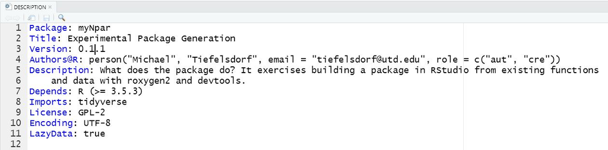

  Then save the file.
- To edit a the code or documentation of a function open the function in the script editor by using R’s file browser. Once you are done save your edits.

## 7.4 Building the Online Help and Namespace

In `RStudio`’s `Build` menu select the option `Document`.

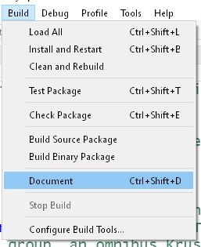

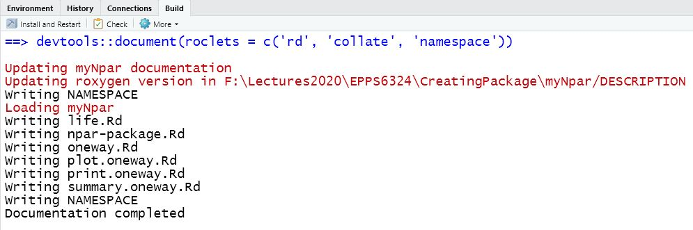

Functions in the library `roxygen2` build the online help documentation. This is save in the sub-directory `man`.

Note: You need to repeat this procedure every time you are updating the header of a function.

Furthermore, the `NAMESPACE` is populated with the necessary information of the *exported* functions and their object relationships. Warning: You almost never need to edit the file `NAMESPACE`.

Once the online help and `NAMESPACE` has been updated, the package can be bundled.

## 7.5 Building the Package Bundle

To build the package bundle and install the updated package directly into your pool of `R` libraries use the `RStudio` menu `Build > Clean and Rebuild`:

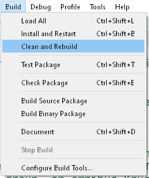

The build information should not have error messages. You can get immediately to your rebuild library in the online help. By default the new package is also loaded into your R session.

[figure not shown]

This approach is convenient during the development phase of your package because it allow rapid updating of your code.

For distribution purposes of your package you need to use the `Console` commands

```r
> devtools::build()
```

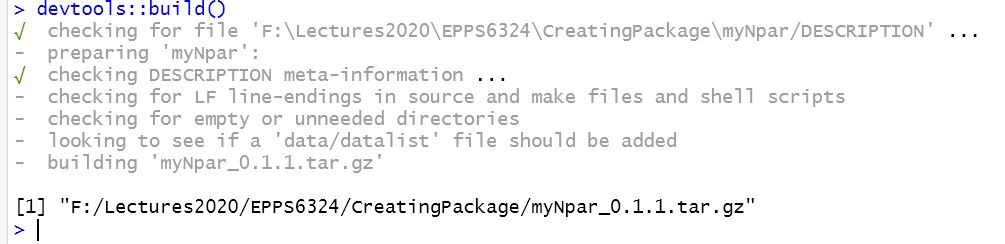

Your new bundled file `myNpar_0.1.1.tar.gz` is saved into the directory above your package project’s directory. It can be installed with on other computers with

```r
> install.packages("Drive:/Path/myNpar_0.1.1.tar.gz", repos=NULL)
```

Using the command `devtools::build()` is also the only way to generate any `vignette` that accompanies your package. `vignettes` are lengthy R markdown documents that demonstrate to your clients what your package can do.

# 8 Submitting your final Package to CRAN

If you want to submit your package to CRAN, your code, data and documentation need to satisfy stringent rules. Consider submitting your package to CRAN only if your bundle passes the check `devtools::check()` function call. More details can be found at http://r-pkgs.had.co.nz/check.html.